# IODS course project

## 2&3 Perform principal component analysis (PCA)

and Draw a biplot displaying the observations - After parcticing, i found that scaling the original dataset is quite critical, otherwise the PCA results would not appropriated as we assumed. - Therefore, here I implemented the PCA with either original human dataset or scaled one. - the biplot of PCA based on non-scalded data, has not show visible relations between parameter and contries, resulting in most countries gathers and haven’t exhibited gathering boundaries; - while for the scaled data, we can find how these 9 variables contributions among countries

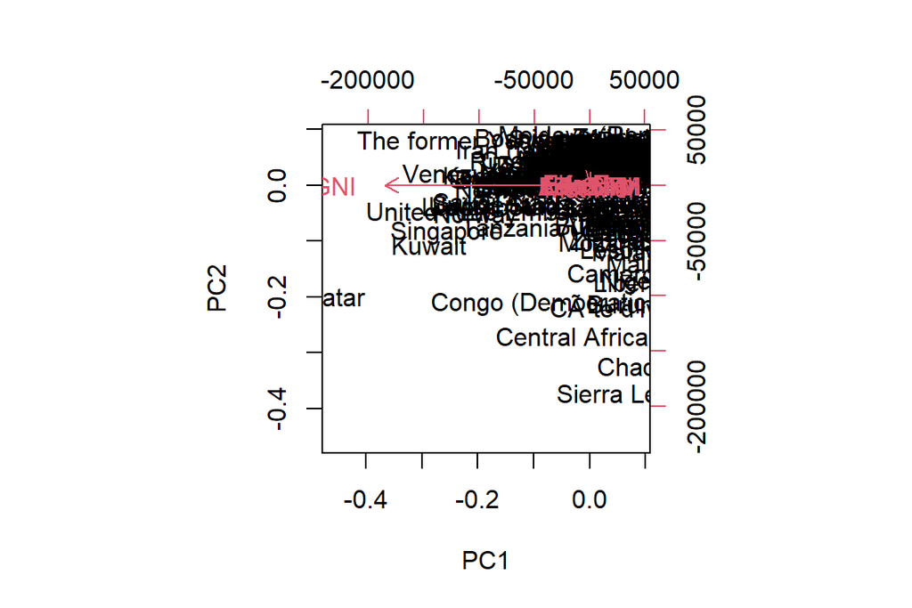

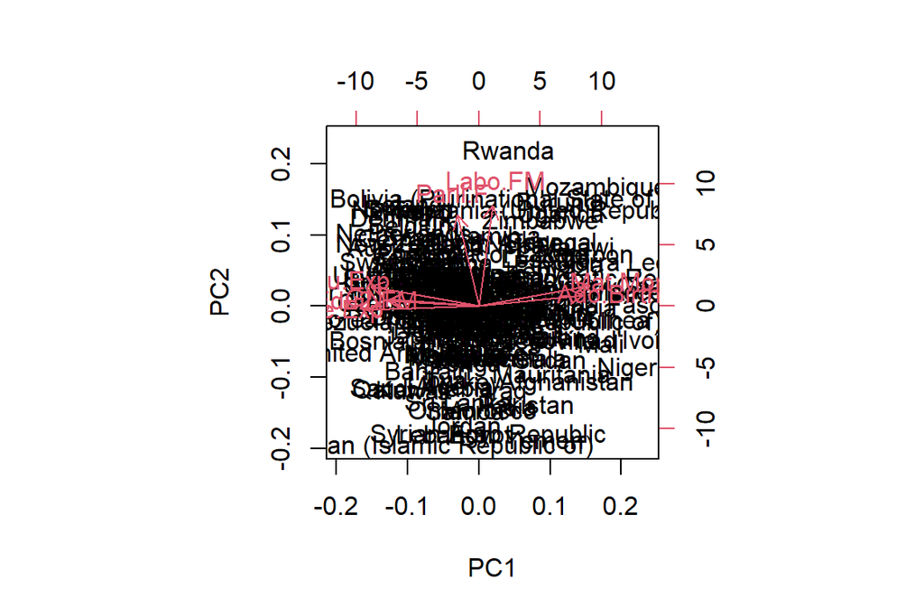

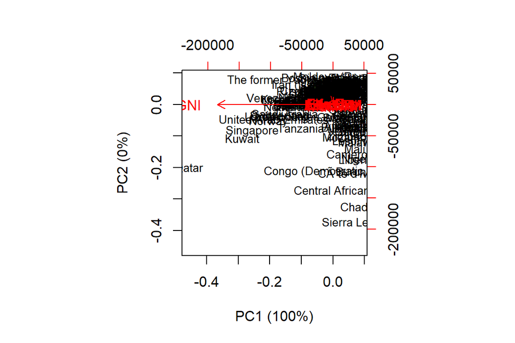

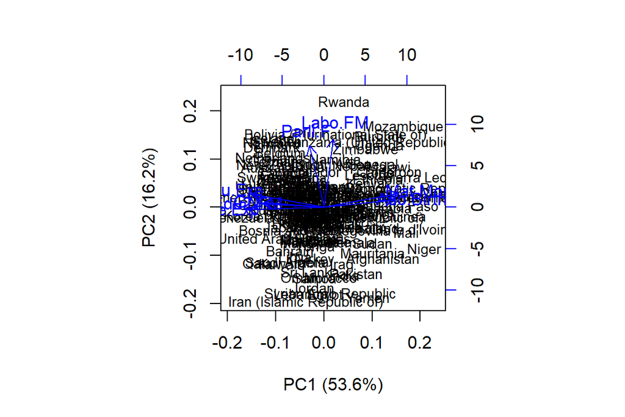

## 4 Give your personal interpretations

- From the view of pca summary, Labo.FM and Parli.F had high component values in PCA2; and the other variables present high weights in PCA1.
- By conducting the PCA, we could reduce the dimensions of variables (nine in this case) to the first two PCAs.
- in PCA1 the ONLY the PC1 was explained the 0.99 variance, indicating that the variable the distribution have not been appropriated separated or presented.
- on the contrary, in PCA2, the first two PCA components explained 0.69 variance, which seems more reasonable and successfully reduced variable dimensions

## 5.1 Load the tea dataset from the package Factominer

- Multiple Correspondence Analysis, MCA ## 5.2 implemented the mca and plot the resutls From the plot, (1) i could see the unpacked and tea shop had high components
2. the variables: ‘where’ and ‘how’ presented high representation weighs.

```
##  [1] "breakfast"        "tea.time"         "evening"          "lunch"
##  [5] "dinner"           "always"           "home"             "work"
##  [9] "tearoom"          "friends"          "resto"            "pub"
## [13] "Tea"              "How"              "sugar"            "how"
## [17] "where"            "price"            "age"              "sex"
## [21] "SPC"              "Sport"            "age_Q"            "frequency"
## [25] "escape.exoticism" "spirituality"     "healthy"          "diuretic"
## [29] "friendliness"     "iron.absorption"  "feminine"         "sophisticated"
## [33] "slimming"         "exciting"         "relaxing"         "effect.on.health"
```

```
##       breakfast     tea.time     evening     lunch     dinner     always home
## 1     breakfast Not.tea time Not.evening Not.lunch Not.dinner Not.always home
## 2     breakfast Not.tea time Not.evening Not.lunch Not.dinner Not.always home
## 3 Not.breakfast     tea time     evening Not.lunch     dinner Not.always home
## 4 Not.breakfast Not.tea time Not.evening Not.lunch     dinner Not.always home
## 5     breakfast Not.tea time     evening Not.lunch Not.dinner     always home
## 6 Not.breakfast Not.tea time Not.evening Not.lunch     dinner Not.always home
##       work     tearoom     friends     resto     pub       Tea   How    sugar
## 1 Not.work Not.tearoom Not.friends Not.resto Not.pub     black alone    sugar
## 2 Not.work Not.tearoom Not.friends Not.resto Not.pub     black  milk No.sugar
## 3     work Not.tearoom     friends     resto Not.pub Earl Grey alone No.sugar
## 4 Not.work Not.tearoom Not.friends Not.resto Not.pub Earl Grey alone    sugar
## 5 Not.work Not.tearoom Not.friends Not.resto Not.pub Earl Grey alone No.sugar
## 6 Not.work Not.tearoom Not.friends Not.resto Not.pub Earl Grey alone No.sugar
##       how       where           price age sex          SPC         Sport age_Q
```

[output cut: 27 more lines]

```
## [1] 300  36
```

```
## 'data.frame':    300 obs. of  36 variables:
##  $ breakfast       : Factor w/ 2 levels "breakfast","Not.breakfast": 1 1 2 2 1 2 1 2 1 1 ...
##  $ tea.time        : Factor w/ 2 levels "Not.tea time",..: 1 1 2 1 1 1 2 2 2 1 ...
##  $ evening         : Factor w/ 2 levels "evening","Not.evening": 2 2 1 2 1 2 2 1 2 1 ...
##  $ lunch           : Factor w/ 2 levels "lunch","Not.lunch": 2 2 2 2 2 2 2 2 2 2 ...
##  $ dinner          : Factor w/ 2 levels "dinner","Not.dinner": 2 2 1 1 2 1 2 2 2 2 ...
##  $ always          : Factor w/ 2 levels "always","Not.always": 2 2 2 2 1 2 2 2 2 2 ...
##  $ home            : Factor w/ 2 levels "home","Not.home": 1 1 1 1 1 1 1 1 1 1 ...
##  $ work            : Factor w/ 2 levels "Not.work","work": 1 1 2 1 1 1 1 1 1 1 ...
##  $ tearoom         : Factor w/ 2 levels "Not.tearoom",..: 1 1 1 1 1 1 1 1 1 2 ...
##  $ friends         : Factor w/ 2 levels "friends","Not.friends": 2 2 1 2 2 2 1 2 2 2 ...
##  $ resto           : Factor w/ 2 levels "Not.resto","resto": 1 1 2 1 1 1 1 1 1 1 ...
##  $ pub             : Factor w/ 2 levels "Not.pub","pub": 1 1 1 1 1 1 1 1 1 1 ...
##  $ Tea             : Factor w/ 3 levels "black","Earl Grey",..: 1 1 2 2 2 2 2 1 2 1 ...
##  $ How             : Factor w/ 4 levels "alone","lemon",..: 1 3 1 1 1 1 1 3 3 1 ...
```

[output cut: 22 more lines]

```
## 'data.frame':    300 obs. of  5 variables:
##  $ Tea  : Factor w/ 3 levels "black","Earl Grey",..: 1 1 2 2 2 2 2 1 2 1 ...
##  $ How  : Factor w/ 4 levels "alone","lemon",..: 1 3 1 1 1 1 1 3 3 1 ...
##  $ how  : Factor w/ 3 levels "tea bag","tea bag+unpackaged",..: 1 1 1 1 1 1 1 1 2 2 ...
##  $ sugar: Factor w/ 2 levels "No.sugar","sugar": 2 1 1 2 1 1 1 1 1 1 ...
##  $ where: Factor w/ 3 levels "chain store",..: 1 1 1 1 1 1 1 1 2 2 ...
```

```
##
## Call:
## MCA(X = tea_time, graph = FALSE, method = "indicator")
##
##
## Eigenvalues
##                        Dim.1   Dim.2   Dim.3   Dim.4   Dim.5   Dim.6   Dim.7
## Variance               0.335   0.309   0.257   0.224   0.198   0.184   0.172
## % of var.             16.762  15.441  12.866  11.181   9.924   9.188   8.625
## Cumulative % of var.  16.762  32.204  45.069  56.250  66.174  75.362  83.987
##                        Dim.8   Dim.9  Dim.10
## Variance               0.141   0.105   0.075
## % of var.              7.031   5.249   3.734
## Cumulative % of var.  91.017  96.266 100.000
##
## Individuals (the 3 first)
##              Dim.1    ctr   cos2    Dim.2    ctr   cos2    Dim.3    ctr   cos2
## 1         | -0.325  0.105  0.088 | -0.288  0.090  0.069 |  0.305  0.120  0.078
## 2         | -0.259  0.067  0.037 | -0.074  0.006  0.003 |  0.789  0.806  0.343
## 3         | -0.403  0.162  0.242 | -0.283  0.086  0.119 |  0.217  0.061  0.070
##
## 1         |
## 2         |
## 3         |
##
## Categories (the 3 first)
##               Dim.1     ctr    cos2  v.test     Dim.2     ctr    cos2  v.test
## black     |   0.473   3.294   0.073   4.681 |   0.198   0.627   0.013   1.961 |
## Earl Grey |  -0.265   2.689   0.126  -6.147 |   0.088   0.319   0.014   2.033 |
## green     |   0.487   1.558   0.029   2.962 |  -0.956   6.515   0.113  -5.813 |
##             Dim.3     ctr    cos2  v.test
## black       1.045  20.945   0.358  10.342 |
## Earl Grey  -0.462  10.689   0.386 -10.737 |
## green       0.360   1.110   0.016   2.190 |
##
## Categorical variables (eta2)
##             Dim.1 Dim.2 Dim.3
## Tea       | 0.126 0.115 0.421 |
## How       | 0.076 0.220 0.385 |
## how       | 0.708 0.503 0.008 |
```

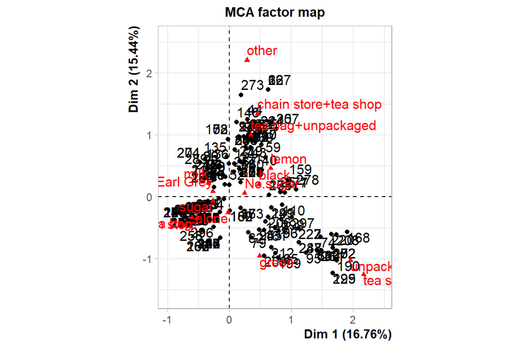

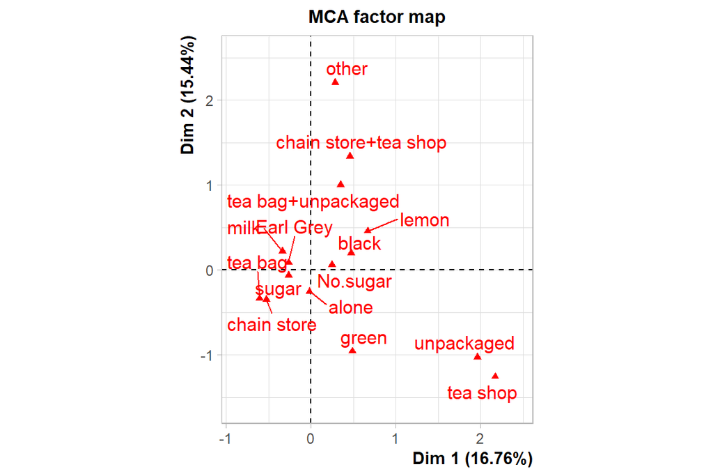

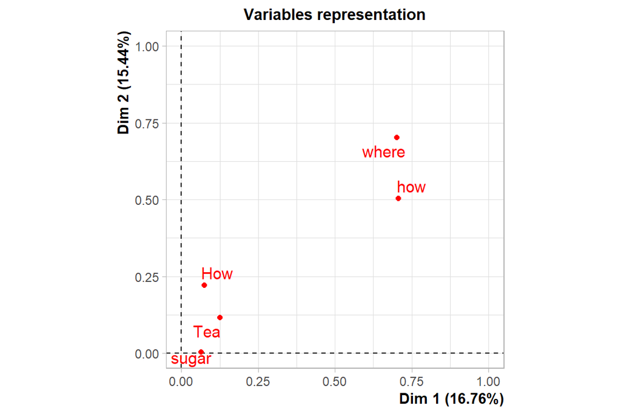

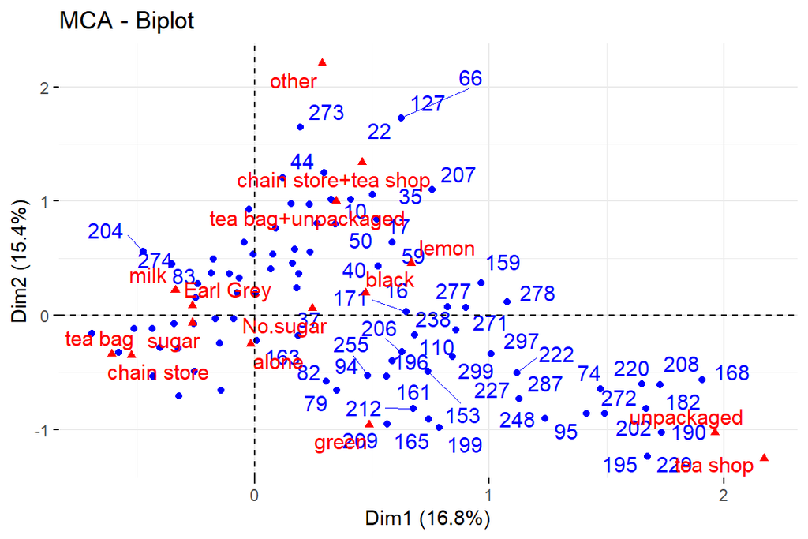

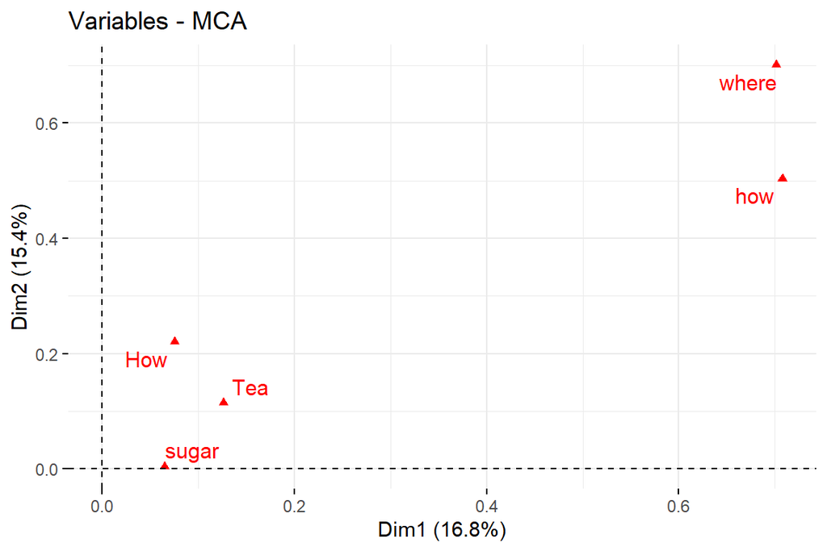

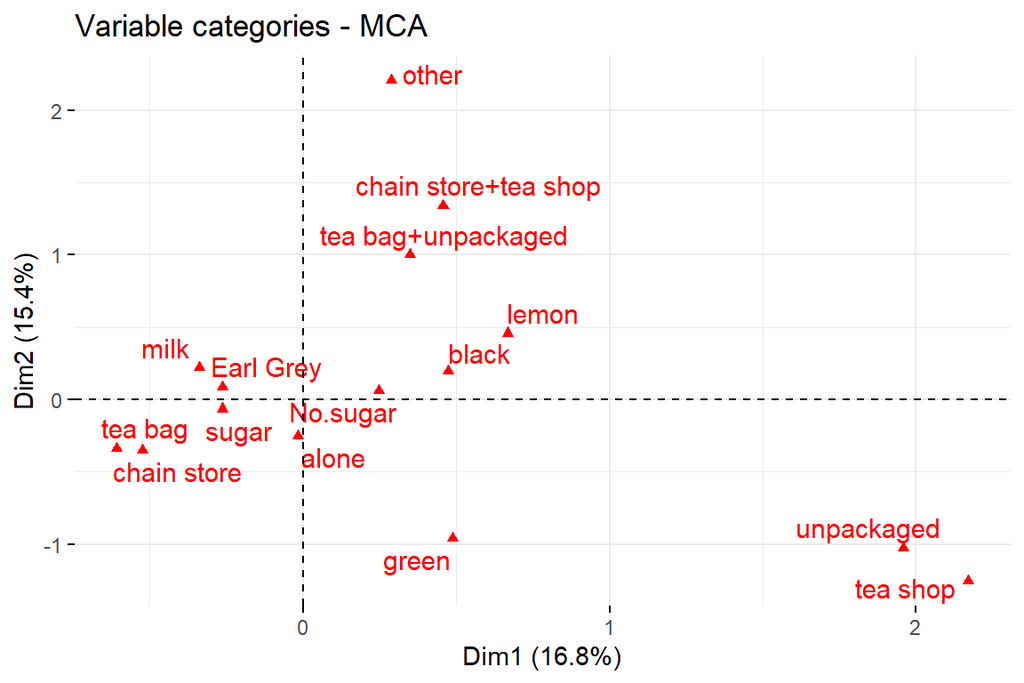

# Chapter 6 Analysis of longitudinal data

```r
options(knitr.duplicate.label = "allow")
```

```r
date()
```

```
## [1] "Thu Dec 09 10:04:49 2021"
```

## 1 Load the longitudinal bprsl and ratsl datasets

```r
library(dplyr)
library(tidyr)
library(ggplot2)

# Set the working directory
setwd("Z:/Course/Opendata science/IODS-project")

# read the longitudinal and original datasets
rats <- read.table("https://raw.githubusercontent.com/KimmoVehkalahti/MABS/master/Examples/data/rats.txt", sep="", header=TRUE)
bprs <- read.csv("https://raw.githubusercontent.com/KimmoVehkalahti/MABS/master/Examples/data/BPRS.txt", sep="", header=TRUE)

bprsl <- read.csv('data/bprsl.csv', sep = ",", header = TRUE, stringsAsFactors = TRUE)
ratsl <- read.csv('data/ratsl.csv', sep = ",", header = TRUE, stringsAsFactors = TRUE)

bprsl <- bprsl[,-1]
ratsl <- ratsl[,-1]

# Dimension of two form of data
dim(rats) #16*13
```

```
## [1] 16 13
```

```r
dim(ratsl) #176*5
```

```
## [1] 176   5
```

```r
dim(bprs) #40*11
```

```
## [1] 40 11
```

```r
dim(bprsl) #360*5
```

```
## [1] 360   5
```

## 2.1 Summary Measure Analysis for ratsl data, the Chapter8 analysis

## Graphical Displays and Summary Measure Approach

Interpretations: -1 in ratsl data, the weight ~ Time + Group + ID

-2 Base on graphs, we could see: (1) wight increased with time in all groups

(2)the weight trends clearly separated in three groups:in which group1 had quite low values, and group 2 and 3 shard similar wight regions, from 400-550.

3. Additionally, one ID in Group2 exceptional high weight, ranged from 550 to 640.

```r
names(ratsl)
```

```
## [1] "ID"     "Group"  "time"   "weight" "Time"
```

```r
str(ratsl)
```

```
## 'data.frame':    176 obs. of  5 variables:
##  $ ID    : int  1 2 3 4 5 6 7 8 9 10 ...
##  $ Group : int  1 1 1 1 1 1 1 1 2 2 ...
##  $ time  : Factor w/ 11 levels "WD1","WD15","WD22",..: 1 1 1 1 1 1 1 1 1 1 ...
##  $ weight: int  240 225 245 260 255 260 275 245 410 405 ...
##  $ Time  : int  1 1 1 1 1 1 1 1 1 1 ...
```

```r
# Convert Group and ID as factor varibles
ratsl$ID <- as.factor(ratsl$ID)
ratsl$Group <- as.factor(ratsl$Group)
ratsl$Time <- as.factor(ratsl$Time)
str(ratsl)
```

```
## 'data.frame':    176 obs. of  5 variables:
##  $ ID    : Factor w/ 16 levels "1","2","3","4",..: 1 2 3 4 5 6 7 8 9 10 ...
##  $ Group : Factor w/ 3 levels "1","2","3": 1 1 1 1 1 1 1 1 2 2 ...
##  $ time  : Factor w/ 11 levels "WD1","WD15","WD22",..: 1 1 1 1 1 1 1 1 1 1 ...
##  $ weight: int  240 225 245 260 255 260 275 245 410 405 ...
##  $ Time  : Factor w/ 11 levels "1","8","15","22",..: 1 1 1 1 1 1 1 1 1 1 ...
```

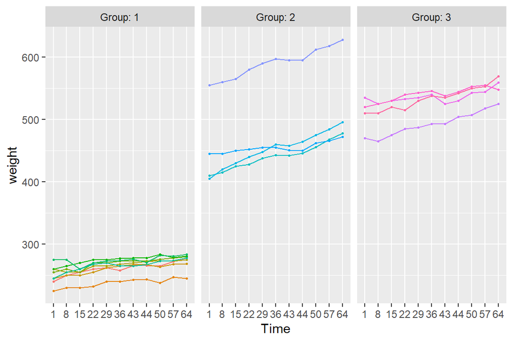

```r
# Draw the plot of ratsl
# Plot1
ggplot(ratsl, aes(x = Time, y = weight, color = ID)) +
  geom_point(size=0.5) +
  geom_line(aes(group = ID)) +
  facet_grid(. ~ Group, labeller = label_both) +
  theme(legend.position = "none") +
  scale_y_continuous(limits = c(min(ratsl$weight), max(ratsl$weight)))
```

## 2.2 Summary Measure Analysis- Line plots

### the standarized plots and mean+sd plots

Interpretations: -1 plot standardized weight, the differences between groups of weight trends with time were more apparent.

-2 In group1 and 3, there was one ID showed a significant low standardized weight trend line, while in group2, one curve/line posed in high value regions.

-3 here, i could more clearly found that the weight development with time varied in three groups, in which upward and downward trend both presented.

-4 the plot2 clearly shown the values gaps among three groups and illustrated their temporal trends, in which group 2 and 3 visible increased while group relatively stable.

```r
# Based on previous plots, I firstly group ratsl by Time
# Standardise the variable weight by Time
ratsl.gb <- ratsl %>%
  group_by(Group, Time) %>%
  mutate(stdweight = (weight - mean(weight))/sd(weight)) %>%
  ungroup()
dim(ratsl) #176*5
```

```
## [1] 176   5
```

```r
dim(ratsl.gb) #176*6
```

```
## [1] 176   6
```

```r
names(ratsl)
```

```
## [1] "ID"     "Group"  "time"   "weight" "Time"
```

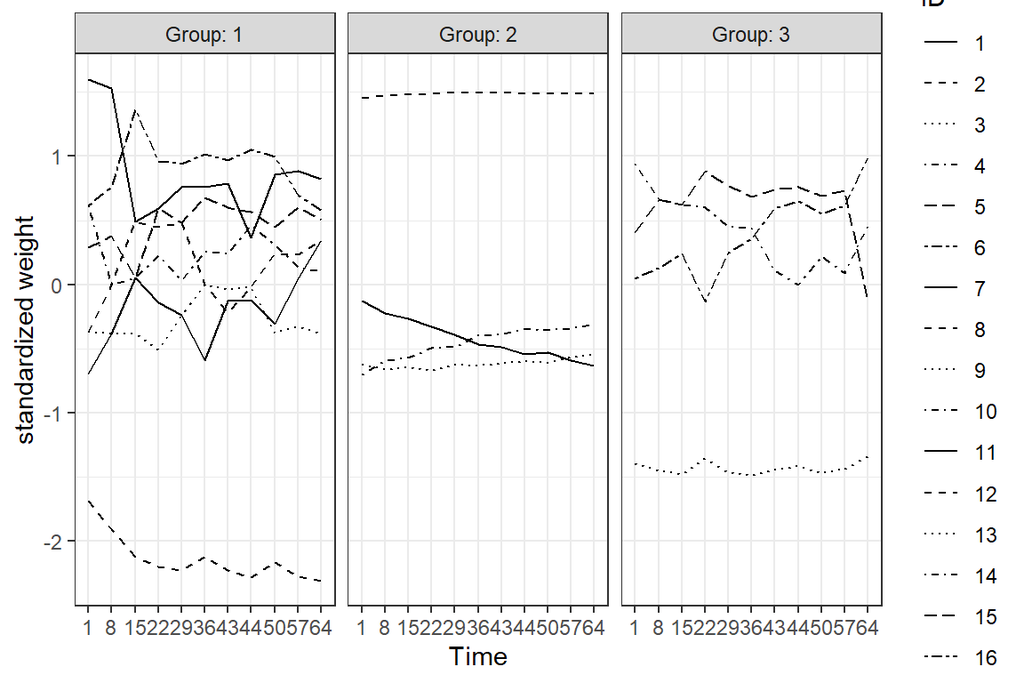

```r
# Plot again with the standardised weight
ggplot(ratsl.gb, aes(x = Time, y = stdweight, linetype = ID)) +
  scale_linetype_manual(values = rep(1:10, times=4)) +
  geom_line(aes(group = ID)) +
  facet_grid(. ~ Group, labeller = label_both) +
  scale_y_continuous(name = "standardized weight") +
  theme_bw()
```

```r
# Number/levels of Times
n <- ratsl$Time %>% unique() %>% length()

# Summary rats with mean and standard error of weight by Group and Time
ratss.gb <- ratsl %>%
  group_by(Group, Time) %>%
  summarise(mean = mean(weight), se = sd(weight)/sqrt(n)) %>%
  ungroup()
ratss.gb %>% summary()
```

```
##  Group       Time         mean             se
##  1:11   1      : 3   Min.   :250.6   Min.   : 3.074
##  2:11   8      : 3   1st Qu.:269.5   1st Qu.: 4.101
##  3:11   15     : 3   Median :486.5   Median : 7.358
##         22     : 3   Mean   :424.7   Mean   :10.703
##         29     : 3   3rd Qu.:518.2   3rd Qu.:21.047
##         36     : 3   Max.   :550.2   Max.   :22.390
##         (Other):15
```

```r
dim(ratss.gb) #33*4
```

```
## [1] 33  4
```

```r
# Glimpse the grouped ratss data
glimpse(ratss.gb)
```

```
## Rows: 33
## Columns: 4
## $ Group <fct> 1, 1, 1, 1, 1, 1, 1, 1, 1, 1, 1, 2, 2, 2, 2, 2, 2, 2, 2, 2, 2, 2~
## $ Time  <fct> 1, 8, 15, 22, 29, 36, 43, 44, 50, 57, 64, 1, 8, 15, 22, 29, 36, ~
## $ mean  <dbl> 250.625, 255.000, 254.375, 261.875, 264.625, 265.000, 267.375, 2~
## $ se    <dbl> 4.589478, 3.947710, 3.460116, 4.100800, 3.333956, 3.552939, 3.30~
```

```r
# Plot the mean profiles
names(ratss.gb) #"Group" "Time"  "mean"  "se"
```

```
## [1] "Group" "Time"  "mean"  "se"
```

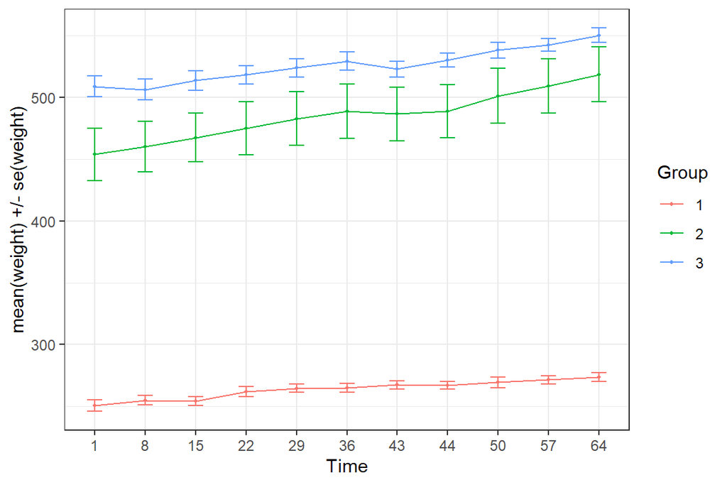

```r
ggplot(ratss.gb, aes(x = Time, y = mean, color = Group)) +
  geom_point(size=0.8) +
  geom_line(aes(group = Group)) +
  geom_errorbar(aes(ymin = mean - se, ymax = mean + se), width=0.3) +
  scale_y_continuous(name = "mean(weight) +/- se(weight)") +
  theme_bw()
```

## 2.3 Summary Measure Analysis- box plots

### found out the outliers

```r
# Create a summary data by GROUP and ID
ratss.gb2 <- ratsl %>%
  group_by(Group, ID) %>%
  summarise(mean=mean(weight)) %>%
  ungroup()
dim(ratss.gb2) #16*3
```

```
## [1] 16  3
```

```r
# Glimpse the data
glimpse(ratss.gb2)
```

```
## Rows: 16
## Columns: 3
## $ Group <fct> 1, 1, 1, 1, 1, 1, 1, 1, 2, 2, 2, 2, 3, 3, 3, 3
## $ ID    <fct> 1, 2, 3, 4, 5, 6, 7, 8, 9, 10, 11, 12, 13, 14, 15, 16
## $ mean  <dbl> 261.0909, 237.6364, 260.1818, 266.5455, 269.4545, 274.7273, 274.~
```

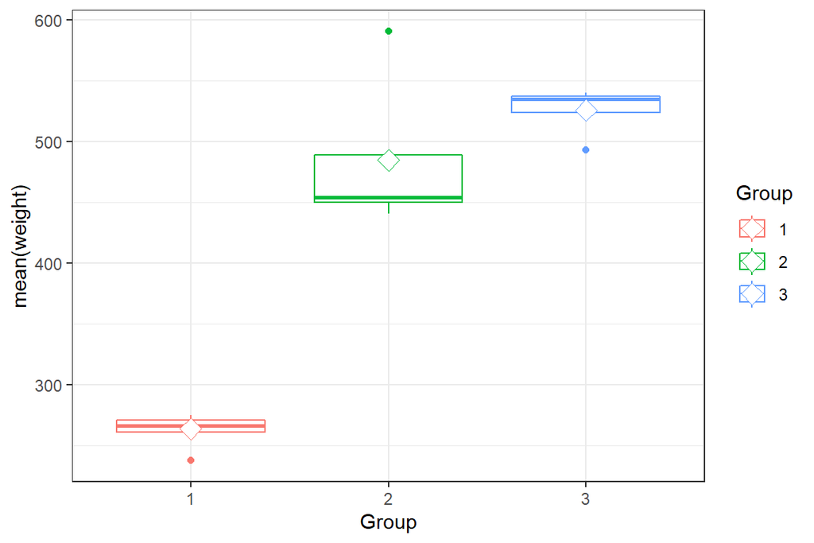

```r
# Draw a boxplot of the mean versus group
ggplot(ratss.gb2, aes(x = Group, y = mean, color = Group)) +
  geom_boxplot() +
  stat_summary(fun = "mean", geom = "point", shape=23, size=4, fill = "white") +
  scale_y_continuous(name = "mean(weight)") +
  theme_bw()
```

```r
# Remove the outliers
ratss.gb3 <- ratss.gb2 %>%
  filter((Group==1 & mean > 250)|(Group==2 & mean < 550)| (Group==3 & mean > 500))
dim(ratss.gb3) #15*3
```

```
## [1] 13  3
```

```r
dim(ratss.gb2) #16*3
```

```
## [1] 16  3
```

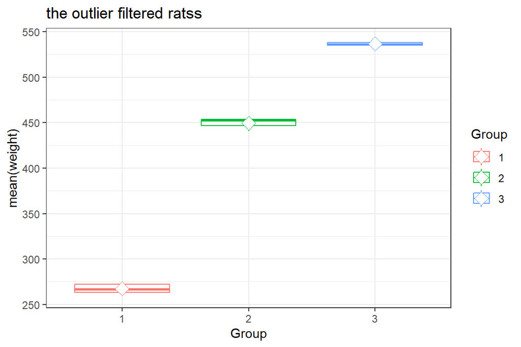

```r
# Draw the new boxplot of the mean versus group
ggplot(ratss.gb3, aes(x = Group, y = mean, color = Group)) +
  geom_boxplot() +
  stat_summary(fun = "mean", geom = "point", shape=23, size=4, fill = "white") +
  scale_y_continuous(name = "mean(weight)") +
  ggtitle("the outlier filtered ratss") +
  theme_bw()
```

-1 the linear model,fit1, reported that the group variable is significant

-2 the fit2 revealed that time and group both significantly impact weight

```r
# Fit the linear model with the mean as the response
fit1 <- lm(mean ~ Group, data = ratss.gb3)

# Compute the analysis of variance table for the fitted model with anova()
anova(fit1)
```

```
## Analysis of Variance Table
##
## Response: mean
##           Df Sum Sq Mean Sq F value    Pr(>F)
## Group      2 175958   87979  2577.4 2.721e-14 ***
## Residuals 10    341      34
## ---
## Signif. codes:  0 '***' 0.001 '**' 0.01 '*' 0.05 '.' 0.1 ' ' 1
```

```r
# Fit the linear model with the mean as the response
names(ratss.gb)
```

```
## [1] "Group" "Time"  "mean"  "se"
```

```r
# "Group" "Time"  "ID"    "mean"  "se"

fit2 <- lm(mean ~ Group + Time, data = ratss.gb)

# Compute the analysis of variance table for the fitted model with anova()
anova(fit2)
```

```
## Analysis of Variance Table
##
## Response: mean
##           Df Sum Sq Mean Sq  F value    Pr(>F)
## Group      2 437104  218552 4908.646 < 2.2e-16 ***
## Time      10   5625     563   12.634  1.34e-06 ***
## Residuals 20    890      45
## ---
## Signif. codes:  0 '***' 0.001 '**' 0.01 '*' 0.05 '.' 0.1 ' ' 1
```